# Final Project- Sarcopenia Risk Predictor

Group Members:

1. Feven Belay - 20027
2. Lidia Yohannes- 20029

# 1. Bussiness Understanding

The focus is on addressing age-related loss of skeletal muscle mass and function, known as sarcopenia, which is significantly associated with adverse health outcomes such as increased risk of falls, fractures, physical frailty, mobility limitation, and premature mortality. Beyond aging itself, factors such as smoking, physical inactivity, malnutrition, and chronic comorbid diseases including hypertension (HT), diabetes mellitus (DM), coronary artery disease (CAD), hyperlipidemia, and obesity also contribute to muscle loss and decline in muscle function. Prevention of sarcopenia-related morbidity and mortality among aging individuals depends on early detection and treatment, as well as understanding the relationships between muscle loss, decline in muscle function, physical performance, and potential predictors such as demographic, lifestyle, and health-related factors.

# 2. Data Understanding

The dataset consists of 1303 samples with 39 columns, where the target variable of interest is 'SARCOPENIA'. The dataset includes various demographic, lifestyle, and health-related features such as age, weight, height, smoking status, alcohol consumption, presence of chronic diseases (e.g., DM, HT), and physical characteristics (e.g., grip strength, gait speed). Understanding the dataset involves performing exploratory data analysis (EDA) to examine properties such as the number of samples, features, data types, and missing values. Additionally, data cleaning and preprocessing steps are necessary to address issues such as missing values, outliers, duplicates, and inconsistencies, ensuring that the data is suitable for analysis and modeling. Furthermore, identifying relevant features and understanding their relationships with the target variable through data visualization and analysis are crucial steps in data understanding. This understanding serves as the foundation for developing effective predictive models to address the business problem of sarcopenia detection and prevention.

# 3. Data Exploration

```python
#Importing neccesary libraries
import pandas as pd
import numpy as np
import matplotlib.pyplot as plt
from sklearn.model_selection import train_test_split
from sklearn.preprocessing import LabelEncoder
from sklearn.linear_model import LogisticRegression
from sklearn.ensemble import RandomForestClassifier
from sklearn.ensemble import GradientBoostingClassifier
from sklearn.preprocessing import StandardScaler
from sklearn.metrics import classification_report, confusion_matrix
import pickle
from google.colab import files
```

```python
# Load the data
data = pd.read_csv('/content/DataSampled.csv')
```

```python
# viewing the first five rows of the data
data.head(5)
```

|  | MMSE | Age | Weight | Height | Waist | Hip | Smoking | Smoking (packet/year) | Alcohol | DM | ... | Exercise | LowCST | CST | Gait speed | Low grip strength | Grip strength | SARCOPENIA | STAR | BMI | Gender |
| --- | --- | --- | --- | --- | --- | --- | --- | --- | --- | --- | --- | --- | --- | --- | --- | --- | --- | --- | --- | --- | --- |
| 0 | NaN | 64 | 66.0 | 155.0 | 89.0 | 104.0 | 0.0 | 0 | 0 | 0 | ... | 0 | 0.0 | 8.1 | 1.28 | 0.0 | 28.0 | 0.0 | 1.00 | 27.40 | F |
| 1 | NaN | 53 | 55.0 | 150.0 | 77.0 | 97.0 | 0.0 | 0 | 0 | 0 | ... | NaN | 0.0 | 8.0 | 1.47 | 1.0 | 16.0 | 0.0 | 1.84 | 24.40 | F |
| 2 | 24.0 | 56 | 56.0 | 150.0 | 112.0 | 125.0 | 0.0 | 0 | 0 | 0 | ... | 0 | 0.0 | 11.7 | 0.80 | 0.0 | 23.0 | 0.0 | 1.48 | 36.00 | F |
| 3 | NaN | 58 | 75.0 | 160.0 | 113.0 | NaN | 0.0 | 0 | 0 | 1 | ... | 0 | 1.0 | 18.0 | 1.34 | 0.0 | 23.0 | 0.0 | 1.12 | 29.30 | F |
| 4 | 30.0 | 55 | 72.0 | 157.0 | 98.0 | 104.0 | 1.0 | 4 | 0 | 0 | ... | 1-2/week | NaN | 10.9 | 1.09 | NaN | 21.0 | 0.0 | 1.45 | 29.21 | F |

5 rows × 39 columns

```python
# Viewing the name of the columns
data.columns
```

```
Index(['MMSE', 'Age', 'Weight ', 'Height ', 'Waist ', 'Hip', 'Smoking',
       ' Smoking (packet/year)', '  Alcohol', 'DM ', 'DM duration', 'İnsülin',
       ' DM drug', 'Hiperlipidemi', 'Dyslipidemia duration',
       'Dyslipidemia drugs ', 'KAH', 'KAH duration', 'Hipotiroidi', 'ASTIM',
       'KOAH', 'OP', 'Other(s)', 'HT', 'Anti-HT drug type', 'HT duration',
       'Education', 'Occupation', 'Working Status', 'Exercise', 'LowCST',
       'CST', 'Gait speed', 'Low grip strength', 'Grip strength', 'SARCOPENIA',
       'STAR', 'BMI', 'Gender'],
      dtype='object')
```

```python
# Display basic information and first few rows
data.info()
```

```
<class 'pandas.core.frame.DataFrame'>
RangeIndex: 1303 entries, 0 to 1302
Data columns (total 39 columns):
 #   Column                  Non-Null Count  Dtype
---  ------                  --------------  -----
 0   MMSE                    812 non-null    float64
 1   Age                     1303 non-null   int64
 2   Weight                  1302 non-null   float64
 3   Height                  1301 non-null   float64
 4   Waist                   1297 non-null   float64
 5   Hip                     1296 non-null   float64
 6   Smoking                 1302 non-null   float64
 7    Smoking (packet/year)  1301 non-null   object
 8     Alcohol               1303 non-null   object
 9   DM                      1303 non-null   int64
```

[output cut: 31 more lines]

```python
# Summary statistics for numerical features
data.describe()
```

|  | MMSE | Age | Weight | Height | Waist | Hip | Smoking | DM | DM duration | İnsülin | ... | HT | HT duration | LowCST | CST | Gait speed | Low grip strength | Grip strength | SARCOPENIA | STAR | BMI |
| --- | --- | --- | --- | --- | --- | --- | --- | --- | --- | --- | --- | --- | --- | --- | --- | --- | --- | --- | --- | --- | --- |
| count | 812.000000 | 1303.000000 | 1302.000000 | 1301.000000 | 1297.000000 | 1296.000000 | 1302.000000 | 1303.000000 | 1289.000000 | 1297.000000 | ... | 1303.000000 | 1261.000000 | 1113.000000 | 1303.000000 | 1300.000000 | 1166.000000 | 1303.000000 | 1302.000000 | 1295.000000 | 1301.000000 |
| mean | 27.519704 | 61.348427 | 76.849693 | 160.322513 | 99.747880 | 109.384645 | 0.321813 | 0.303147 | 2.850202 | 0.060910 | ... | 0.634689 | 5.778699 | 0.318059 | 11.236761 | 0.988775 | 0.220412 | 26.947045 | 0.188940 | 1.226873 | 30.033651 |
| std | 2.767765 | 9.724303 | 13.701356 | 10.022912 | 12.568456 | 11.819345 | 0.467351 | 0.459795 | 6.048845 | 0.239257 | ... | 0.481702 | 7.513770 | 0.465932 | 4.449019 | 0.281349 | 0.414702 | 9.291133 | 0.391611 | 0.308437 | 5.484643 |
| min | 13.000000 | 44.000000 | 42.000000 | 1.590000 | 58.000000 | 15.000000 | 0.000000 | 0.000000 | 0.000000 | 0.000000 | ... | 0.000000 | 0.000000 | 0.000000 | 1.100000 | 0.250000 | 0.000000 | 7.000000 | 0.000000 | 0.490000 | 15.800000 |
| 25% | 27.000000 | 53.000000 | 68.000000 | 155.000000 | 92.000000 | 102.000000 | 0.000000 | 0.000000 | 0.000000 | 0.000000 | ... | 0.000000 | 0.000000 | 0.000000 | 8.800000 | 0.780000 | 0.000000 | 20.000000 | 0.000000 | 1.005000 | 26.300000 |
| 50% | 28.000000 | 61.000000 | 75.000000 | 160.000000 | 100.000000 | 108.000000 | 0.000000 | 0.000000 | 0.000000 | 0.000000 | ... | 1.000000 | 2.000000 | 0.000000 | 10.500000 | 0.980000 | 0.000000 | 25.000000 | 0.000000 | 1.200000 | 29.330000 |
| 75% | 30.000000 | 68.000000 | 85.000000 | 166.000000 | 108.000000 | 116.000000 | 1.000000 | 1.000000 | 2.000000 | 0.000000 | ... | 1.000000 | 10.000000 | 1.000000 | 12.600000 | 1.170000 | 0.000000 | 32.000000 | 0.000000 | 1.420000 | 32.900000 |
| max | 30.000000 | 92.000000 | 150.000000 | 192.000000 | 152.000000 | 191.000000 | 1.000000 | 1.000000 | 40.000000 | 1.000000 | ... | 1.000000 | 55.000000 | 1.000000 | 50.000000 | 2.410000 | 1.000000 | 77.000000 | 1.000000 | 2.330000 | 57.100000 |

8 rows × 28 columns

```python
# Check for missing values
missing_values = data.isnull().sum()
print(missing_values)
```

```
MMSE                       491
Age                          0
Weight                       1
Height                       2
Waist                        6
Hip                          7
Smoking                      1
 Smoking (packet/year)       2
  Alcohol                    0
DM                           0
DM duration                 14
İnsülin                      6
 DM drug                   924
Hiperlipidemi                2
Dyslipidemia duration       16
Dyslipidemia drugs        1072
KAH                         42
KAH duration                54
Hipotiroidi                 32
ASTIM                      123
KOAH                        78
OP                         948
Other(s)                  1018
HT                           0
Anti-HT drug type          553
HT duration                 42
Education                   20
Occupation                  66
Working Status              80
Exercise                    20
LowCST                     190
CST                          0
Gait speed                   3
Low grip strength          137
Grip strength                0
SARCOPENIA                   1
STAR                         8
BMI                          2
Gender                       0
dtype: int64
```

```python
# Unique values for categorical columns
for column in data.select_dtypes(include=['object']):
    print(column, ":", data[column].unique())
```

```
 Smoking (packet/year) : ['0' '4' '30' '11.5' '15' '25' '35' '100' '70' '5' '45' '12' '10' '150'
 '40' '14' '1' '0.1' '20' '7' '72' '21' '49' '17' '50' '2' '20/ex-smoker'
 '104' '7.5' '8' '32' 'shisha for 20 years' '60' '18'
 'EX SMOKER 300/YEAR 9 YRS BACK' '3' '6' '13' '80' '46' 'Former Smoker: 3'
 '40/ex-smoker' '9' '88' '65' '12.5' '2.5' 'ex Smoker: 30' '51' '29'
 'ex Smoker: 25' '90' '44' '75' '36' '24' '64' '28' nan '52'
 '30 (ex smoker)' '34' '23' '62' '16' '156' '43' '37' '27' '55'
 'EX SMOKER 3YEARS/ UNLIMITED']
  Alcohol : ['0' 'social' 'Social ' 'Regular' 'regular' 'Social' 'social ']
 DM drug : [nan 'Glicazide' 'Metformin'
 'metformin+sitagliptin+empagliflozin+insülin aspart+insüülin degludec'
 'metformin' 'insulin aspart,insulin glarjin,metformin' 'saksagliptin'
 'metformin,glklazid' 'metformin, insulin glargin' 'METFORMIN+GLIMEPIRIDE'
 'Gliclazide, Linagliptin' 'insulin glarjin,insulin aspart,metformin'
 'linagliptin, metformin' 'METFORMIN+ MINIDIAB'
 'pioglitazon, metformin, sitagliptin'
 'METFORMIN, GLICLAZIDE, SITAGLIPTIN' 'vildagliptin+metformin, gliklazid'
 'sitagliptin, metformin' 'metformin, insulin' 'without drug'
 'Metformin, Gliclazide' 'metformın,detemir,aspart' 'metformın'
 'vildagliptin,empagliflozin,metformin'
 'GLIMEPIRIDE+ METFORMIN/SITAGLIPTIN' 'metformin,insülin ' 'gliklazid'
 'metformin+insulin' 'insuin glarjin,insulin aspart'
 'empagliflozin,insülin glarjin' 'sitagliptin, metformin, gliklazid'
 'Metformin, Gliclazide, Insulin, Vildagliptin'
 'metformin,gliklazid,insulin detemir' 'Insulin' 'Gliclazide, Insulin'
 'Linagliptin' 'linagiltin,metformin,insulin glarjin'
 'pioglitazon, insülin glarjin' 'sitagliptin,metformin,gliklazid'
 'pioglitazon' 'Sitagliptin, metformin' 'Vildagliptin+ insulin'
 'merformin,sitagliptin' 'metformin, insulin 16 ü (akşam) (4 yıl)'
 'insulin' 'insulin aspart,insulin glarjin,linagliptin,metformin'
 'metformin,insülin aspart' 'metformın,ınsulın lıspro' 'insülin '
 'SITAGLIPTIN, METFORMIN' 'metformin, pioglitazon ' 'insülin glarjin'
 'Metformin/Glimepirid' 'insülin aspart,metformin'
 'metformin+gliklazid 60+linagliptin' 'Gliclazide, Sitagliptin'
 'insulin glargine, gliclazide, metformin'
 'empagliflozin, sitagliptin, metformin' 'metformin,gliklazid,akarboz'
 'sitagliptin, metformin, empagliflozin' 'metformine,gliklazide'
 'vildagliptin,metformin,' 'metformin,gliklazid'
 'sitagliptin,metformin,gliklazide' 'vildagliptin, metformin'
 'metformın,gliklazıd,insülin'
```

[output cut: 195 more lines]

```
 'marketer' 'painter']
Working Status : ['Retire' nan 'retired' 'unemployed' 'çalışmıyor'
 'Full-time/part-time work' 'Not working' 'UNEMPLOYED' 'Retired'
 'retired or not working' 'working' 'Çalışmıyor' 'none'
 'emekli veya çalışmıyor' 'Working' 'full time/part-time work' 'evhanımı'
 'not working' 'Emekli' 'Full-time' 'emekli' 'Unemployed' '#REF!'
 'full-time/part-time work' 'full/part time' 'full/part time work'
 'FULL TIME' 'Tam/kısmi zamanlı çalışıyor' 'RETD' 'Abstinence' 'RETIRED'
 'tam/kısmi zamanlı çalışıyor' 'Full time ' 'çalışıyor' 'emekli '
 'full time' 'ÇALIŞIYOR' 'calısıyor' 'Part-time' 'full time work'
 'Not Working' 'part time work' 'FULLTIME' 'Emekli veya çalışmıyor'
 'tam/kısmi zamnalı çalışıyor' 'ull-time/part-time work'
 'actively working']
Exercise : ['0' nan '1-2/week' '3-4/week']
Gender : ['F' 'M' 'F ' 'f']
```

```python
# Distribution of target variable (if applicable)
target_distribution = data['SARCOPENIA'].value_counts(normalize=True)
print(target_distribution)
```

```
SARCOPENIA
0.0    0.81106
1.0    0.18894
Name: proportion, dtype: float64
```

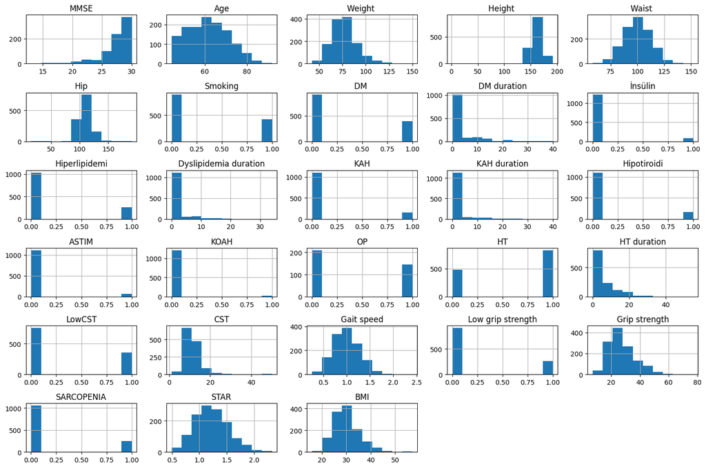

```python
# Histograms for numerical variables
data.hist(figsize=(15, 10))
plt.tight_layout()
plt.show()
```

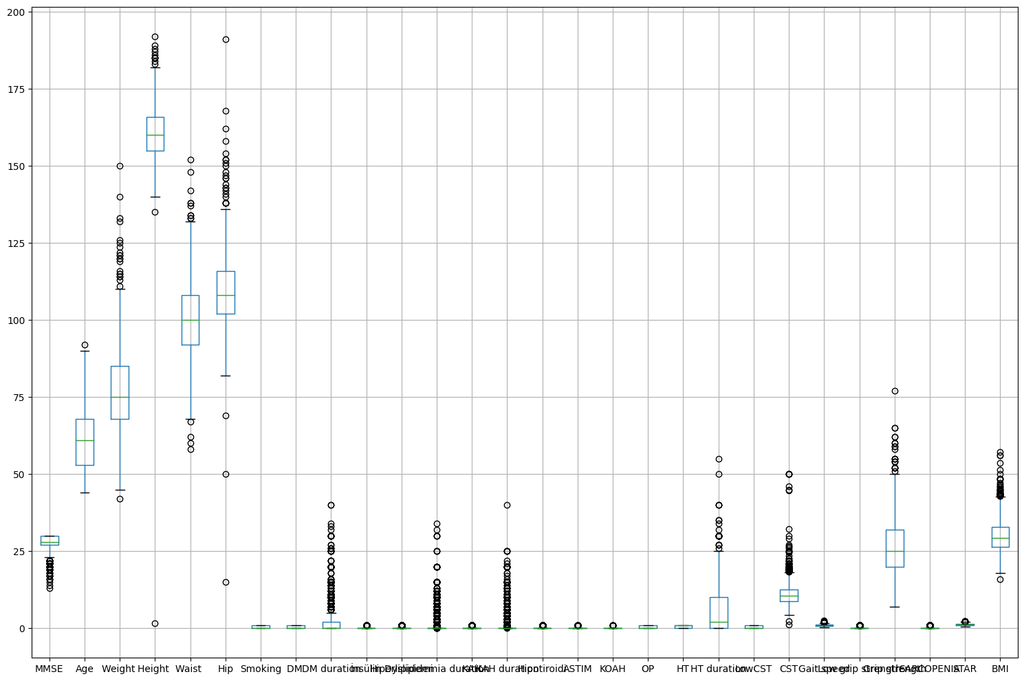

```python
# Boxplots for numerical variables
data.boxplot(figsize=(15, 10))
plt.tight_layout()
plt.show()
```

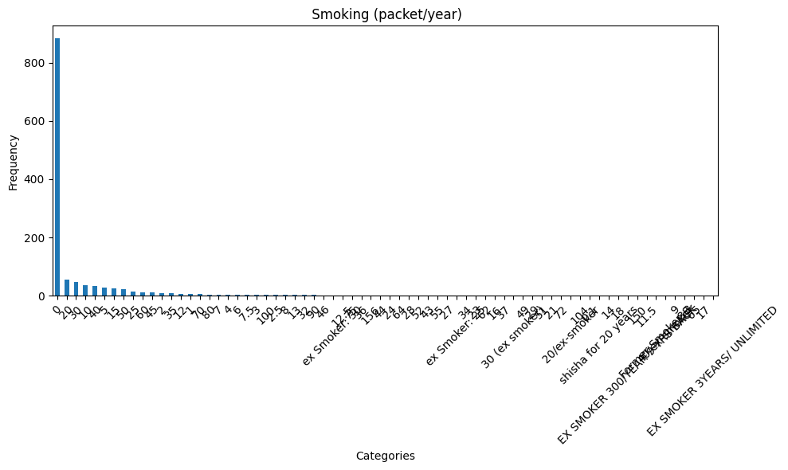

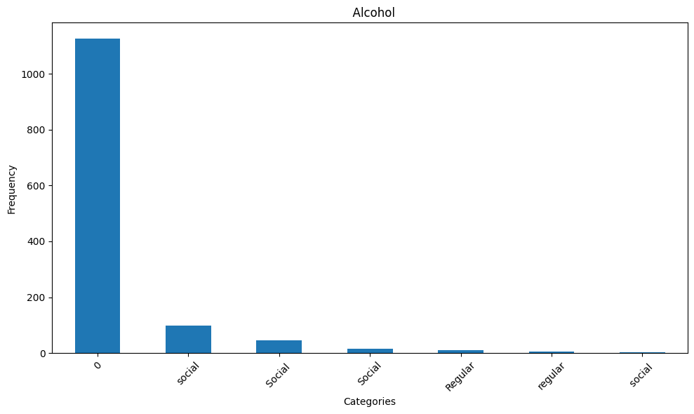

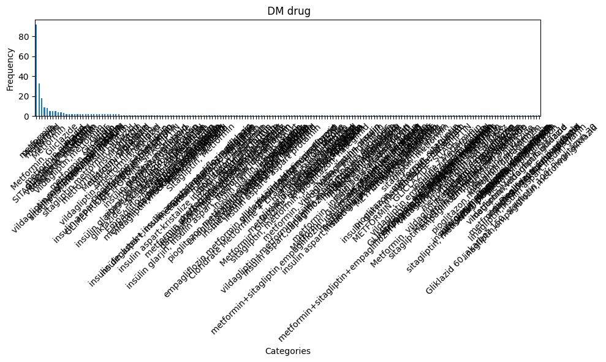

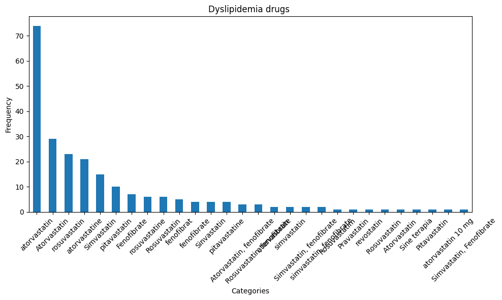

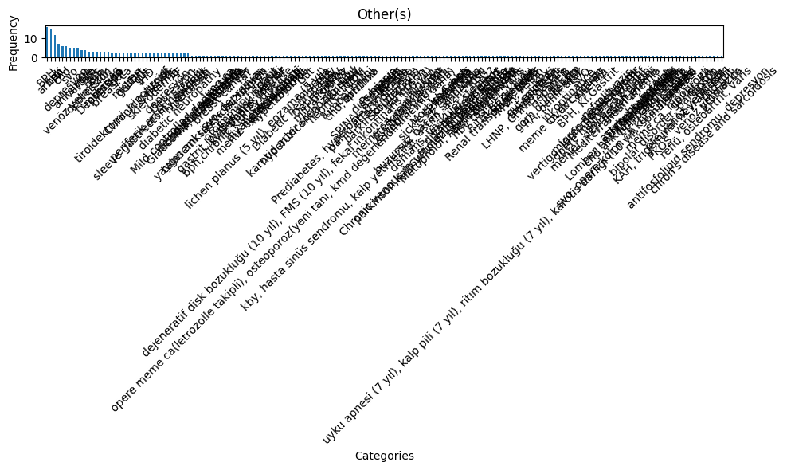

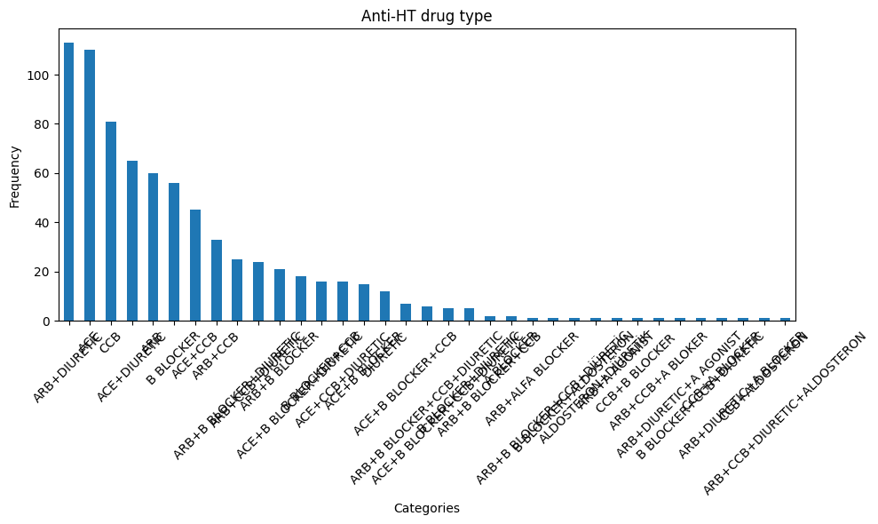

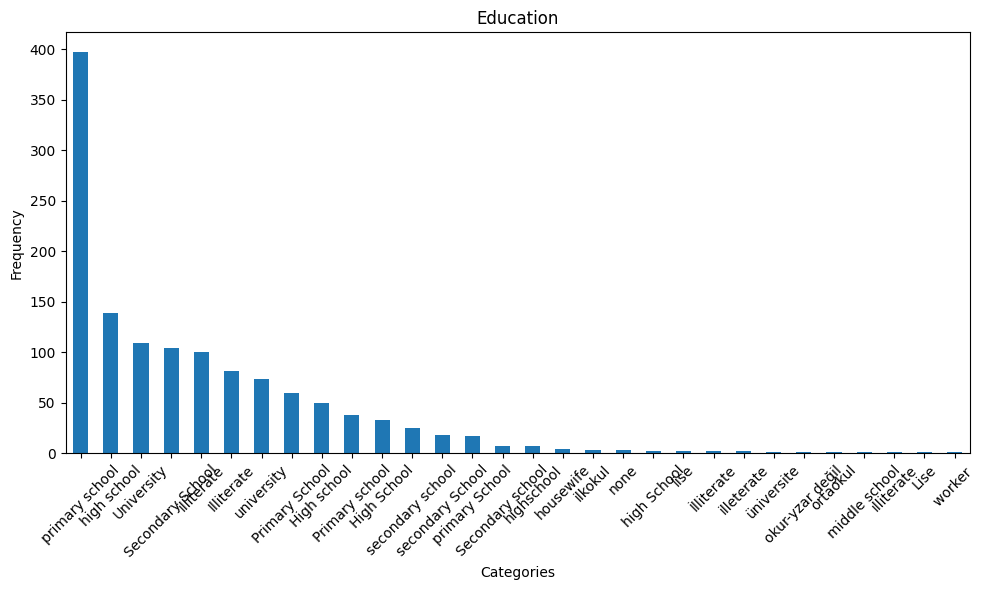

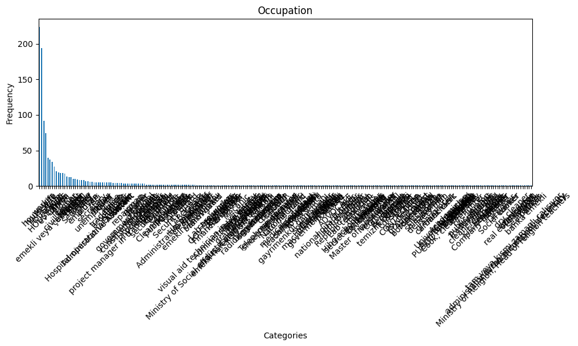

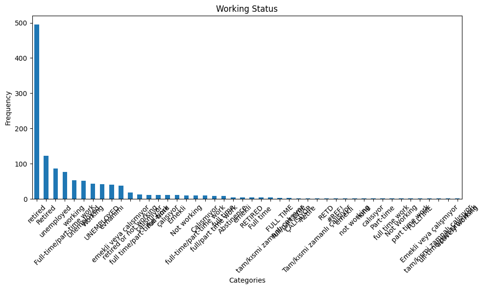

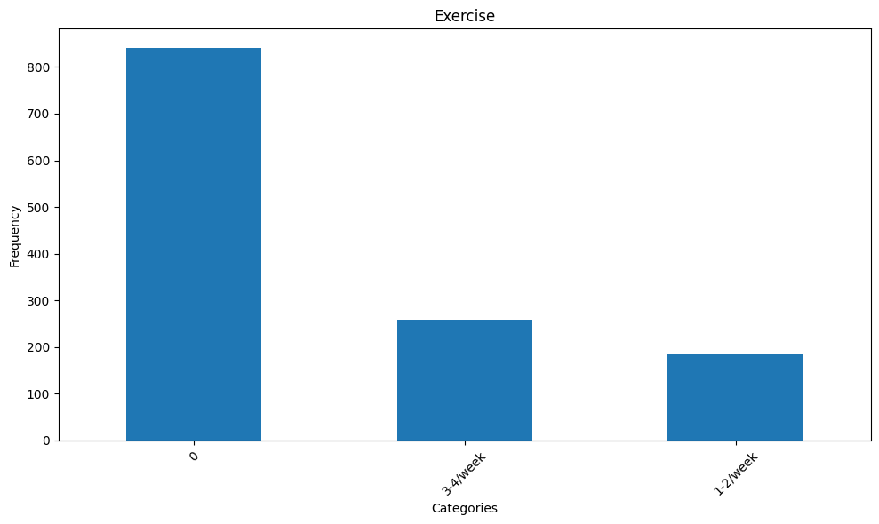

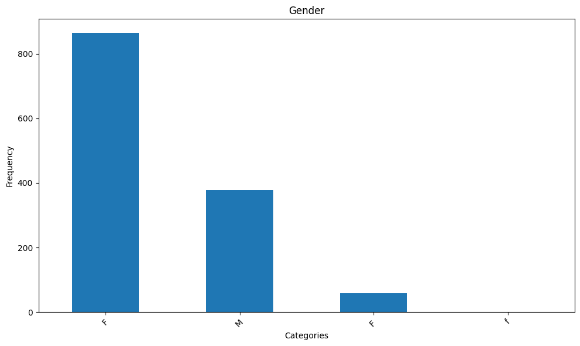

```python
# Bar plots for categorical variables
categorical_columns = data.select_dtypes(include=['object']).columns
for column in categorical_columns:
    plt.figure(figsize=(10, 6))
    data[column].value_counts().plot(kind='bar')
    plt.title(column)
    plt.xlabel('Categories')
    plt.ylabel('Frequency')
    plt.xticks(rotation=45)
    plt.tight_layout()
    plt.show()
```

# 4. Data Cleaning Preprocessing

```python
# Remove 'STAR' column
data.drop('STAR', axis=1, inplace=True)
```

```python
# Convert 'Gender' to numeric
data['Gender'] = data['Gender'].map({'F': 0, 'M': 1})
```

```python
# Inspect unique values in 'Exercise' to decide on encoding
print(data['Exercise'].unique())
```

```
['0' nan '1-2/week' '3-4/week']
```

```python
# Custom encoding or handling for 'Exercise' - Convert text to numeric scale if applicable
exercise_mapping = {
    np.nan: 0, # Assuming NaN means no exercise
    '0': 0,
    '1-2/week': 1,
    '3-5/week': 2,
    'Everyday': 3
}
data['Exercise'] = data['Exercise'].map(exercise_mapping)
```

```python
# Handle 'Smoking' if it's categorical with mixed types (example provided if needed)
# You might need to similarly inspect and handle other categorical/mixed type columns
if data['Smoking'].dtype == 'object':
    # Assuming the need to strip non-numeric part and convert to integer
    data['Smoking'] = data['Smoking'].str.extract('(\d+)').astype(float)
```

```python
# Handling other object-type or categorical columns using LabelEncoder or custom mappings
for col in data.select_dtypes(include=['object']).columns:
    data[col] = LabelEncoder().fit_transform(data[col])
```

```python
# Now handle missing values with median imputation
data.fillna(data.median(), inplace=True)
```

```python
# Remove extra spaces from column names
data.columns = data.columns.str.strip()
```

```python
data.head()
```

|  | MMSE | Age | Weight | Height | Waist | Hip | Smoking | Smoking (packet/year) | Alcohol | DM | ... | Working Status | Exercise | LowCST | CST | Gait speed | Low grip strength | Grip strength | SARCOPENIA | BMI | Gender |
| --- | --- | --- | --- | --- | --- | --- | --- | --- | --- | --- | --- | --- | --- | --- | --- | --- | --- | --- | --- | --- | --- |
| 0 | 28.0 | 64 | 66.0 | 155.0 | 89.0 | 104.0 | 0.0 | 0 | 0 | 0 | ... | 14 | 0.0 | 0.0 | 8.1 | 1.28 | 0.0 | 28.0 | 0.0 | 27.40 | 0.0 |
| 1 | 28.0 | 53 | 55.0 | 150.0 | 77.0 | 97.0 | 0.0 | 0 | 0 | 0 | ... | 46 | 0.0 | 0.0 | 8.0 | 1.47 | 1.0 | 16.0 | 0.0 | 24.40 | 0.0 |
| 2 | 24.0 | 56 | 56.0 | 150.0 | 112.0 | 125.0 | 0.0 | 0 | 0 | 0 | ... | 35 | 0.0 | 0.0 | 11.7 | 0.80 | 0.0 | 23.0 | 0.0 | 36.00 | 0.0 |
| 3 | 28.0 | 58 | 75.0 | 160.0 | 113.0 | 108.0 | 0.0 | 0 | 0 | 1 | ... | 40 | 0.0 | 1.0 | 18.0 | 1.34 | 0.0 | 23.0 | 0.0 | 29.30 | 0.0 |
| 4 | 30.0 | 55 | 72.0 | 157.0 | 98.0 | 104.0 | 1.0 | 36 | 0 | 0 | ... | 44 | 1.0 | 0.0 | 10.9 | 1.09 | 0.0 | 21.0 | 0.0 | 29.21 | 0.0 |

5 rows × 38 columns

```python
# save and download the prepocessed data
data.to_csv('Data.csv', index=False)  # Replace 'data' with your DataFrame variable
from google.colab import files
files.download('Data.csv')
```